# Modelos lineales Ejercicios de la unidad 5 Diagnosis del modelo

### c) Leverage

Calculamos el leverage de cada observación y mostramos los mayores:

```r
> hatv <- hatvalues(model)
> head(sort(hatv,decreasing=T))
```

```
V. De Geneve    La Vallee La Chauxdfnd  Rive Droite    Neuchatel   Porrentruy
   0.4558363    0.3512078    0.2262967    0.2106701    0.2053224    0.1983324
```

Comparamos con el doble del leverage medio $p/n$:

```r
> p <- length(model$coefficients) # k+1
> n <- length(model$fitted.values)
> which(hatv > 2*p/n)
```

```
   La Vallee V. De Geneve
          19           45
```

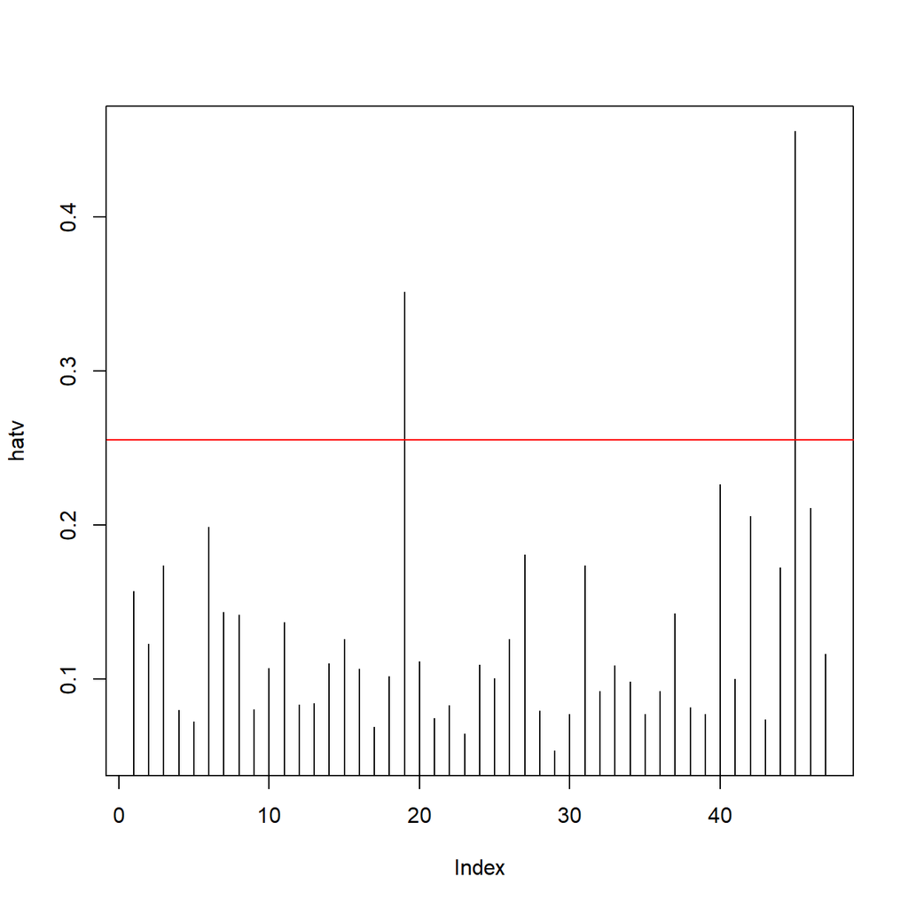

```r
> plot(hatv, type="h")
> abline(h=2*p/n, col="red")
```

Dado que tenemos dos valores por encima del *cutoff*, los observamos detalladamente representándolos en un gráfico.

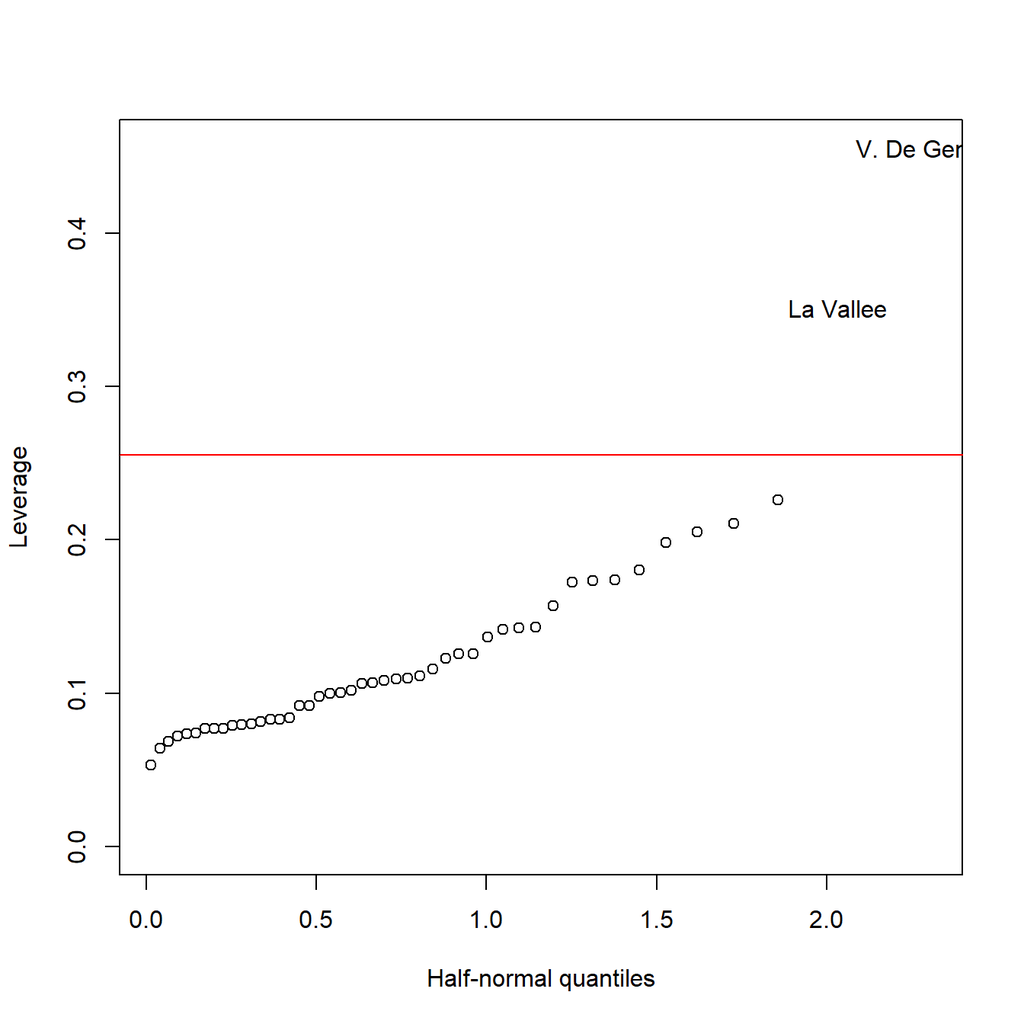

```r
> halfnorm(hatv,nlab=2,labs=row.names(swiss),ylab="Leverage")
> abline(h=2*p/n, col="red")
```

Destacan la ciudad de Ginebra y el distrito de La Vallée con leverages muy por encima de las demás provincias.

### d) Valores atípicos (outliers)

Buscamos las observaciones con un mayor residuo jackknife.

```r
> stud <- rstudent(model)
> head(sort(abs(stud),decreasing=TRUE))
```

```
     Sierre Rive Gauche  Porrentruy  Neuveville   Neuchatel       Glane
   2.445227    2.394471    2.367218    1.816142    1.745412    1.661137
```

```r
> which(abs(stud)>2)
```

```
 Porrentruy      Sierre Rive Gauche
          6          37          47
```

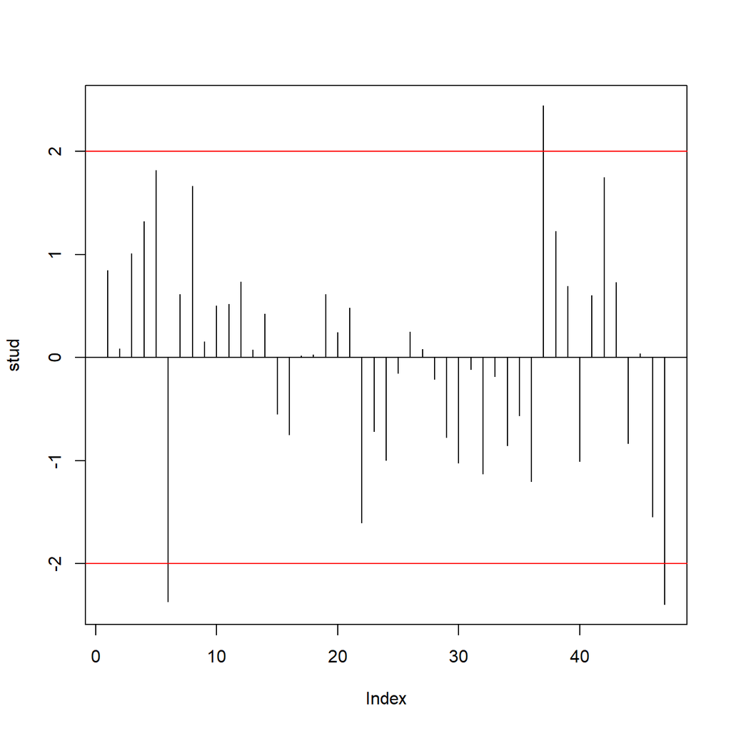

```r
> plot(stud, type="h")
> abline(h=-2, col="red"); abline(h=0); abline(h=2, col="red")
```

Aplicando la corrección de Bonferroni para comparaciones múltiples:

```r
> which(abs(stud) > abs(qt(0.05/(2*n),df=n-p-1)))
```

```
named integer(0)
```

No tenemos ninguna observación por encima del valor crítico.

### e) Observaciones influyentes

**Check for influential points.**

Calculamos la distancia de Cook como medida de la influencia de los puntos.

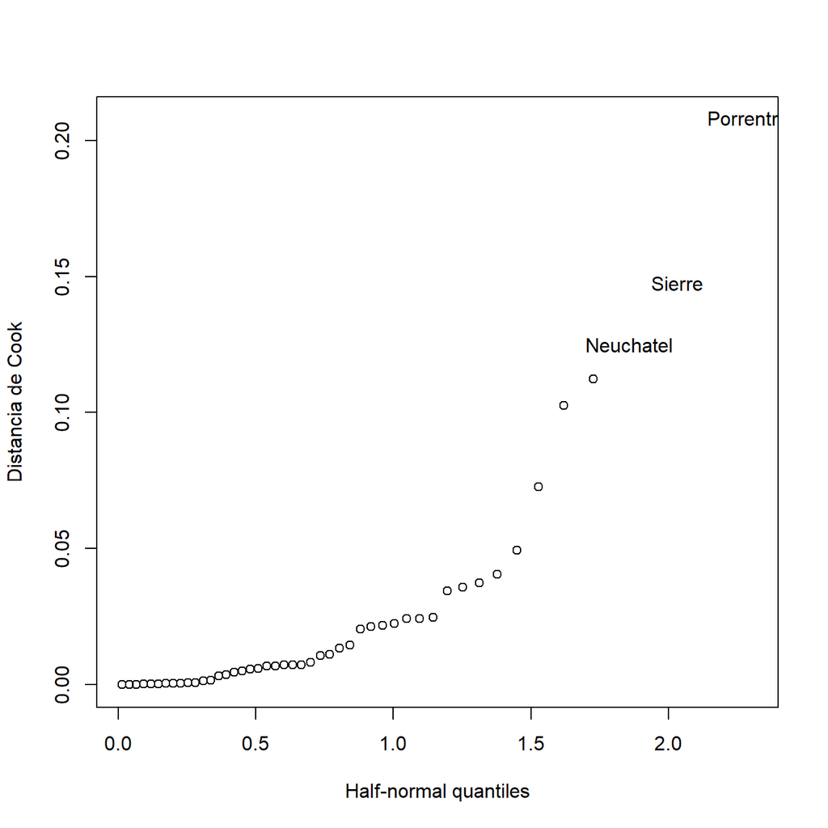

```r
> cook <- cooks.distance(model)
> halfnorm(cook,nlab=3,labs=row.names(swiss),ylab="Distancia de Cook")
```

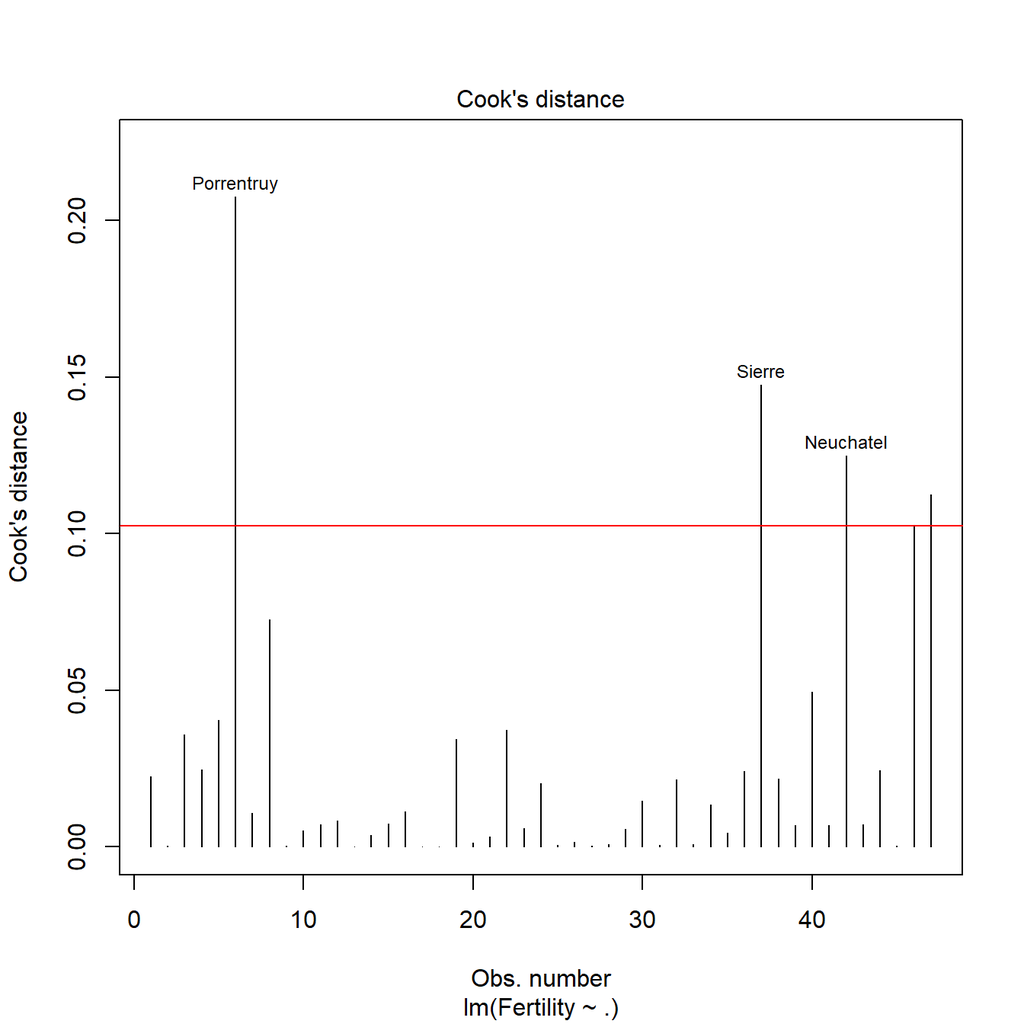

```r
> plot(model, which=4)
> abline(h=4/((n-p-2)), col="red")
```

Encontramos tres puntos bastante más influyentes que los otros, pero menos exageradamente que lo que hemos encontrado en otros problemas, probablemente debido a que en este dataset no coinciden los valores más atípicos con los puntos con más leverage.

### f) Estructura del modelo

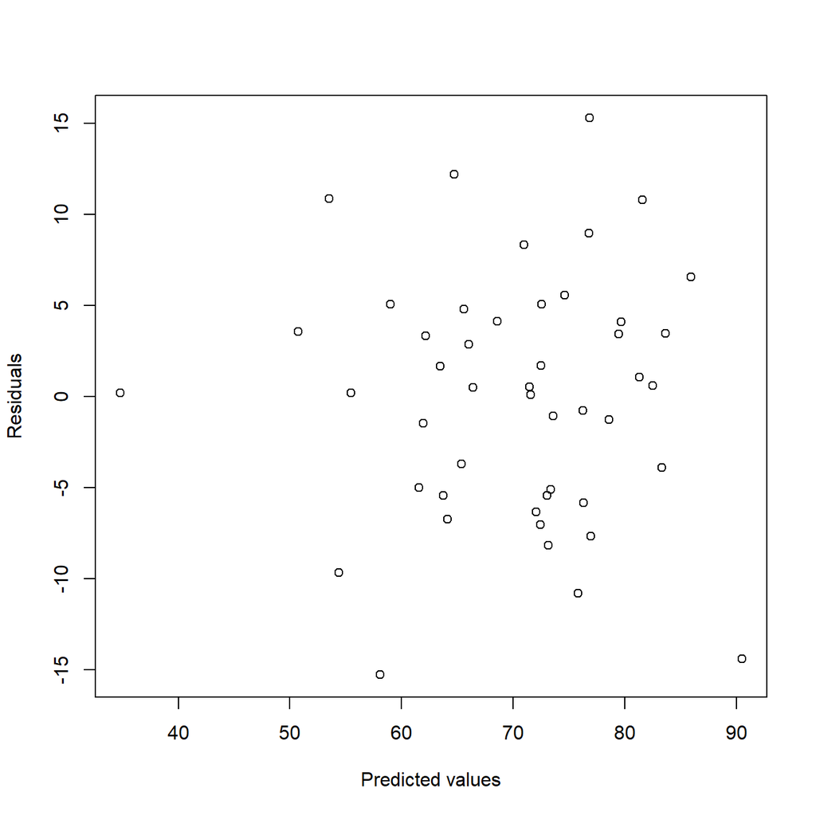

```r
> plot(fitted(model),residuals(model),xlab="Predicted values",ylab="Residuals")
```

La observación de los residuos representados con los valores ajustados no da señales de inadecuación del modelo. Observarlos con cada uno de los predictores tampoco.

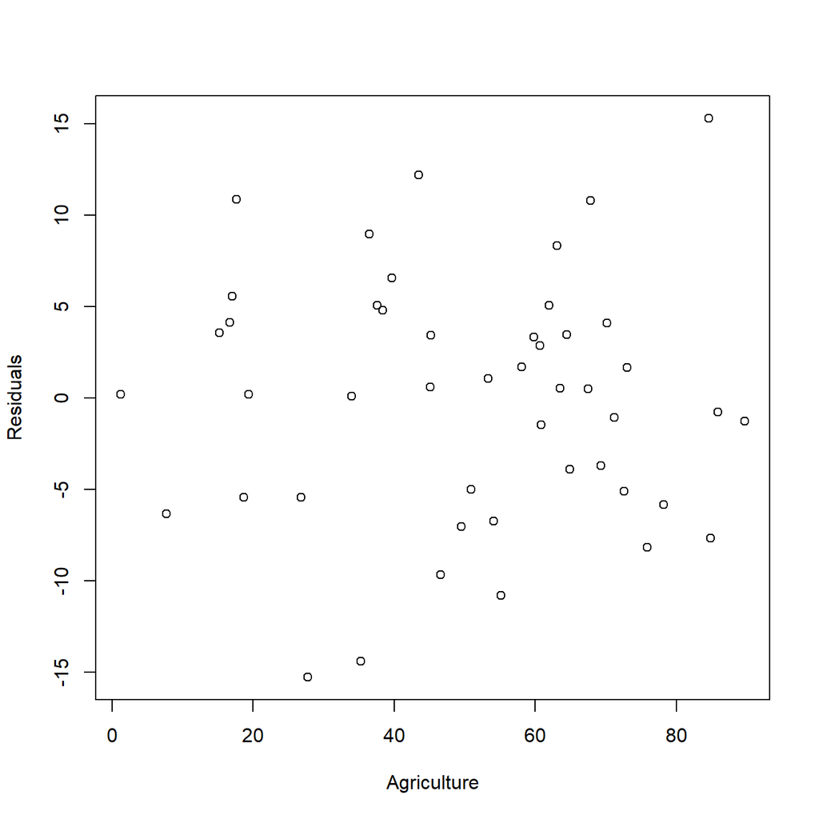

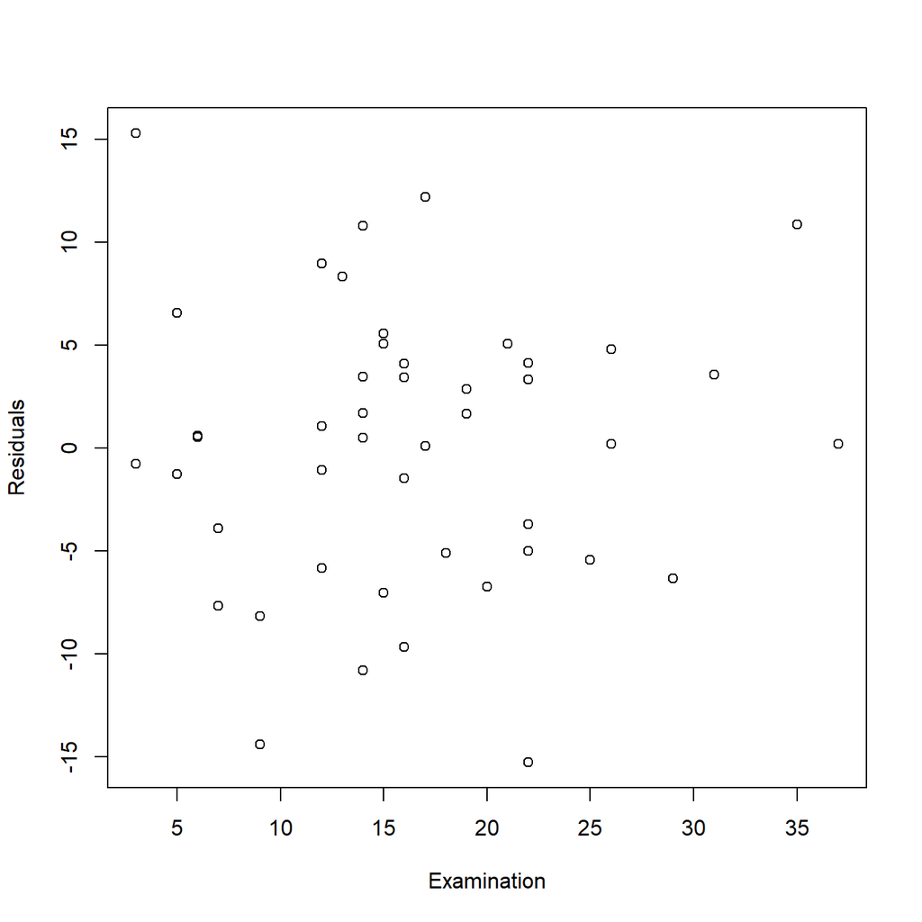

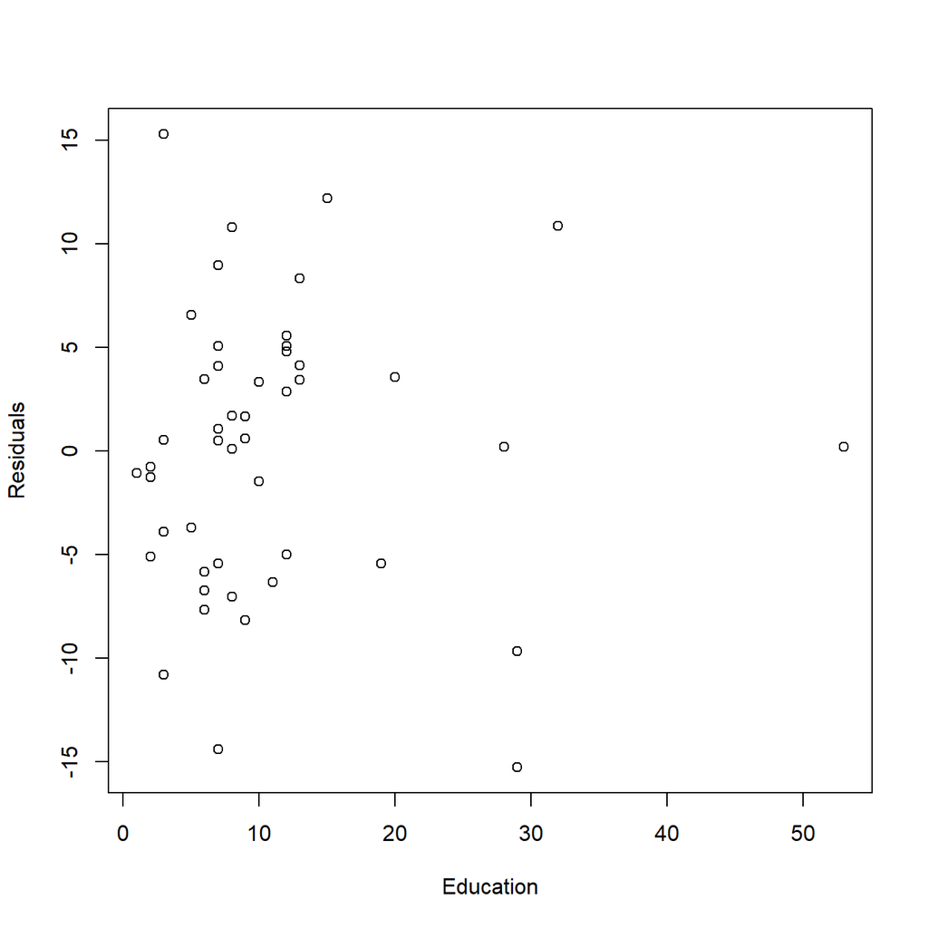

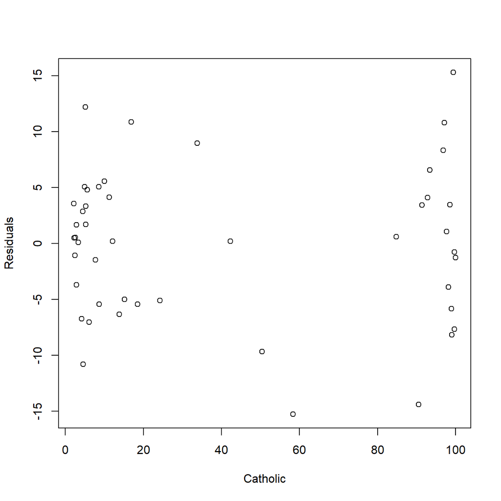

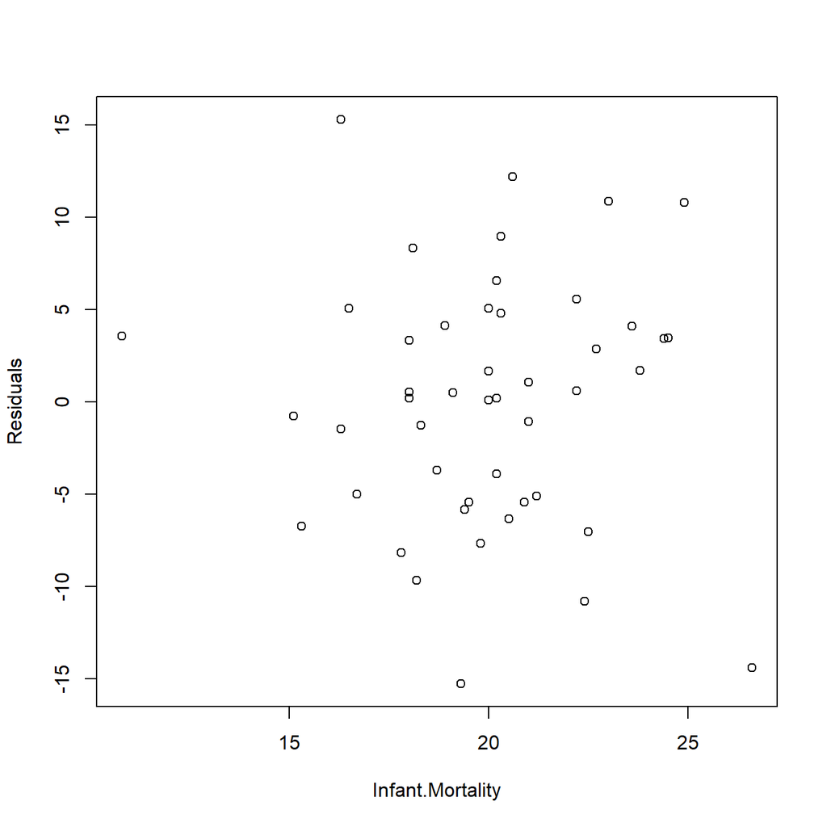

```r
> for (i in 2:6){
+   plot(swiss[,i],residuals(model),xlab=colnames(swiss)[i],ylab="Residuals")
+ }
```

## Problema 6.5. pag. 97

**Using the `cheddar` data, fit a model with `taste` as the response and the other three variables as predictors. Answer the questions posed in the first question.**

Ver la solución del problema 6.1 para más detalles sobre lo que hacemos en éste.

Cargamos los datos y ajustamos el modelo.

```r
> require(faraway)
```

```r
> data(cheddar,package="faraway")
> datos <- cheddar
> head(datos)
```

| taste | Acetic | H2S | Lactic |
| --- | --- | --- | --- |
| 12.3 | 4.543 | 3.135 | 0.86 |
| 20.9 | 5.159 | 5.043 | 1.53 |
| 39.0 | 5.366 | 5.438 | 1.57 |
| 47.9 | 5.759 | 7.496 | 1.81 |
| 5.6 | 4.663 | 3.807 | 0.99 |
| 25.9 | 5.697 | 7.601 | 1.09 |

```r
> model <- lm(taste~.,data=datos)
> sumary(model)
```

```
             Estimate Std. Error t value Pr(>|t|)
(Intercept) -28.87677   19.73542 -1.4632 0.155399
Acetic        0.32774    4.45976  0.0735 0.941980
H2S           3.91184    1.24843  3.1334 0.004247
Lactic       19.67054    8.62905  2.2796 0.031079

n = 30, p = 4, Residual SE = 10.13071, R-Squared = 0.65
```

### a) Varianza constante

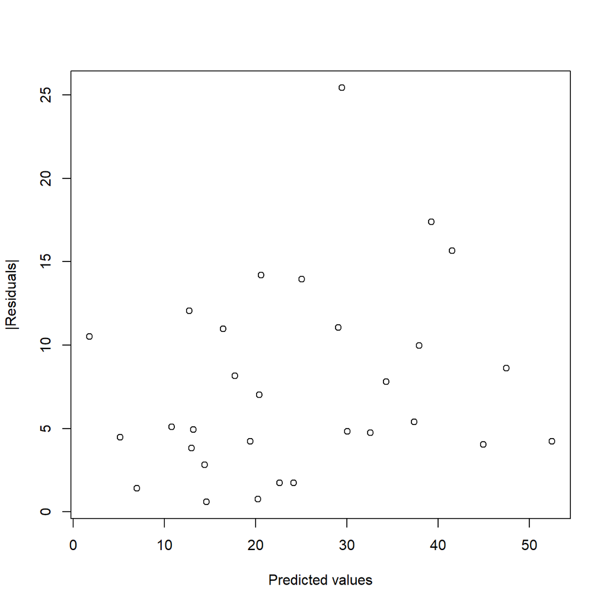

```r
> plot(fitted(model),abs(residuals(model)),xlab="Predicted values",ylab="|Residuals|")
```

```r
> sumary(lm(sqrt(abs(residuals(model)))~fitted(model)))
```

```
              Estimate Std. Error t value  Pr(>|t|)
(Intercept)   2.089068   0.395673  5.2798 1.291e-05
fitted(model) 0.019362   0.014274  1.3564    0.1858

n = 30, p = 2, Residual SE = 1.00878, R-Squared = 0.06
```

No encontramos indicios de heterocedasticidad.

### b) Normalidad

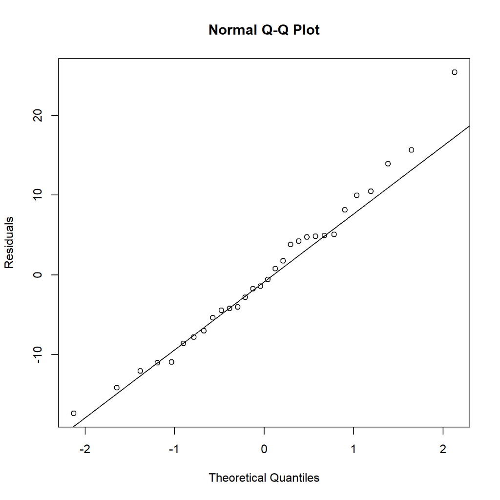

```r
> qqnorm(residuals(model),ylab="Residuals")
> qqline(residuals(model))
```

```r
> shapiro.test(residuals(model))
```

```
    Shapiro-Wilk normality test

data:  residuals(model)
W = 0.98021, p-value = 0.8312
```

No encontramos falta de normalidad.

### c) Leverage

Calculamos el leverage de cada observación y mostramos las mayores:

```r
> hatv <- hatvalues(model)
> head(sort(hatv,decreasing=T))
```

```
       26        20        24         6        30         7
0.2660631 0.2602910 0.2334368 0.2303671 0.2144534 0.2070990
```

```r
> p <- length(model$coefficients) # k+1
> n <- length(model$fitted.values)
> which(hatv > 2*p/n)
```

```
named integer(0)
```

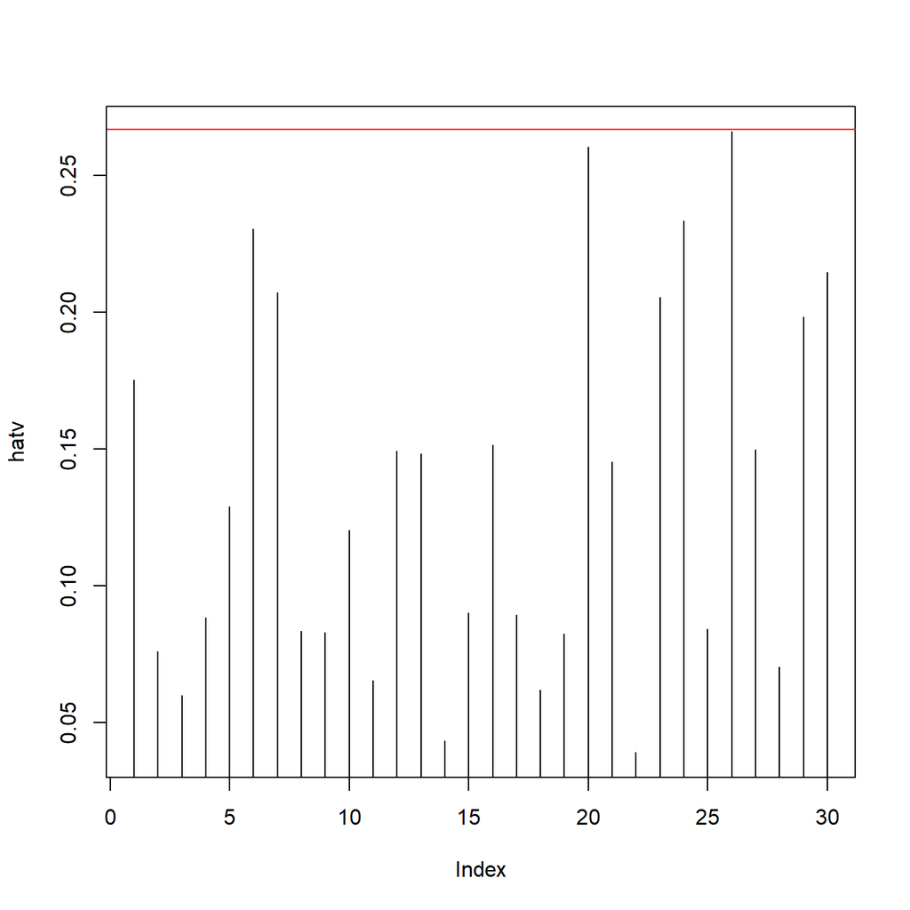

```r
> plot(hatv, type="h")
> abline(h=2*p/n, col="red")
```

No hay valores por encima del doble de la media.

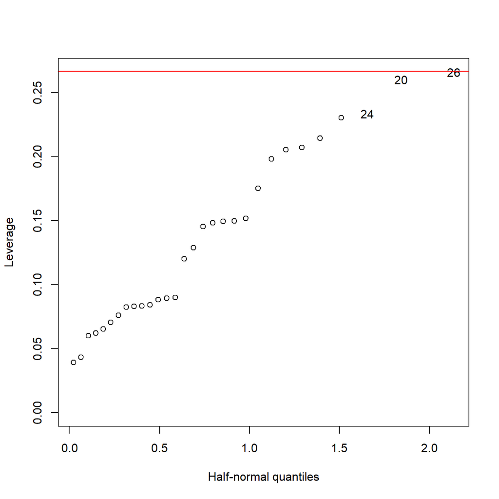

```r
> halfnorm(hatv,nlab=3,labs=row.names(datos),ylab="Leverage")
> abline(h=2*p/n, col="red")
```

### d) Valors atípicos (outliers)

Buscamos las observaciones con un mayor residuo jackknife.

```r
> stud <- rstudent(model)
> head(sort(abs(stud),decreasing=TRUE))
```

```
      15        8       12       18        3       28
3.015470 1.878067 1.739500 1.479078 1.451466 1.247909
```

```r
> which(abs(stud)>2)
```

```
15
15
```

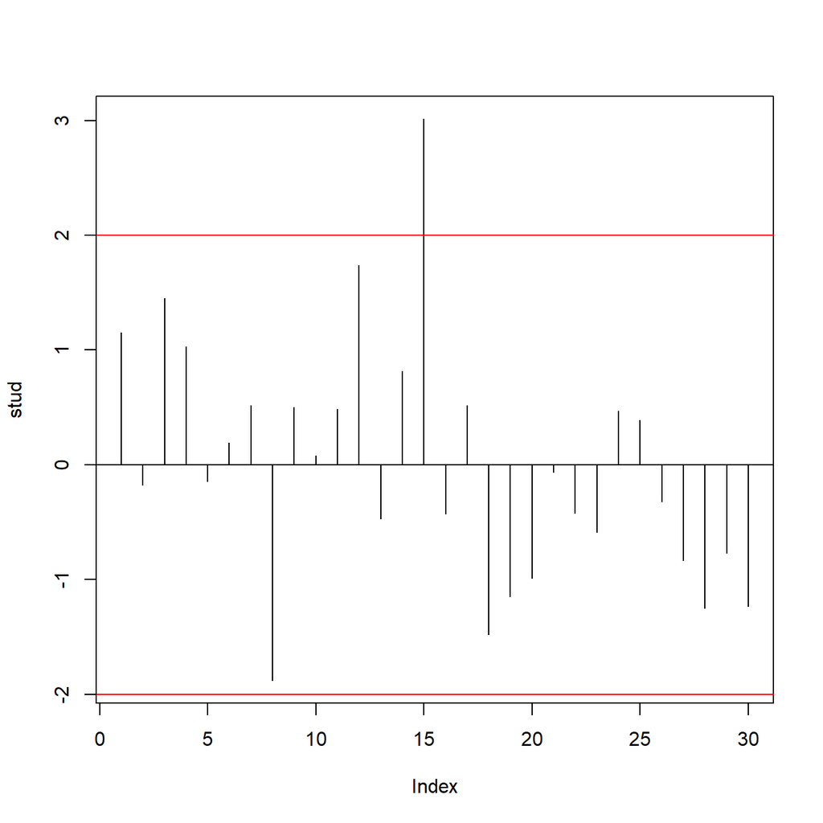

```r
> plot(stud, type="h")
> abline(h=-2, col="red"); abline(h=0); abline(h=2, col="red")
```

Aplicando la corrección de Bonferroni para comparaciones múltiples:

```r
> which(abs(stud) > abs(qt(0.05/(2*n),df=n-p-1)))
```

```
named integer(0)
```

No tenemos ninguna observación por encima del valor crítico.

### e) Observacions influyentes

**Check for influential points.**

Calculamos la distancia de Cook como medida de la influencia de los puntos y la representamos contra los cuartiles de una distribución seminormal.

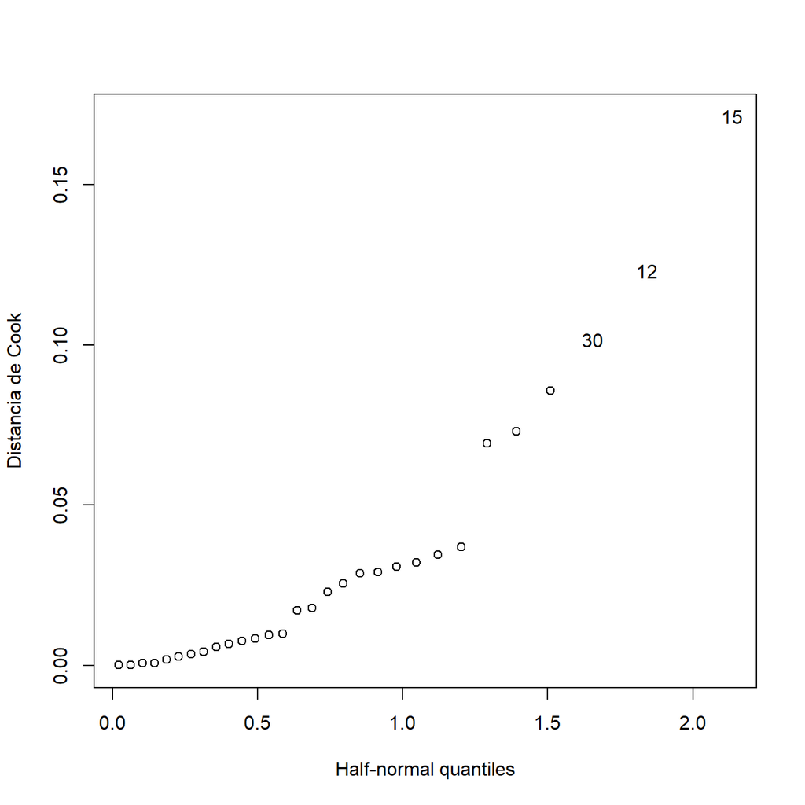

```r
> cook <- cooks.distance(model)
> halfnorm(cook,nlab=3,labs=row.names(datos),ylab="Distancia de Cook")
```

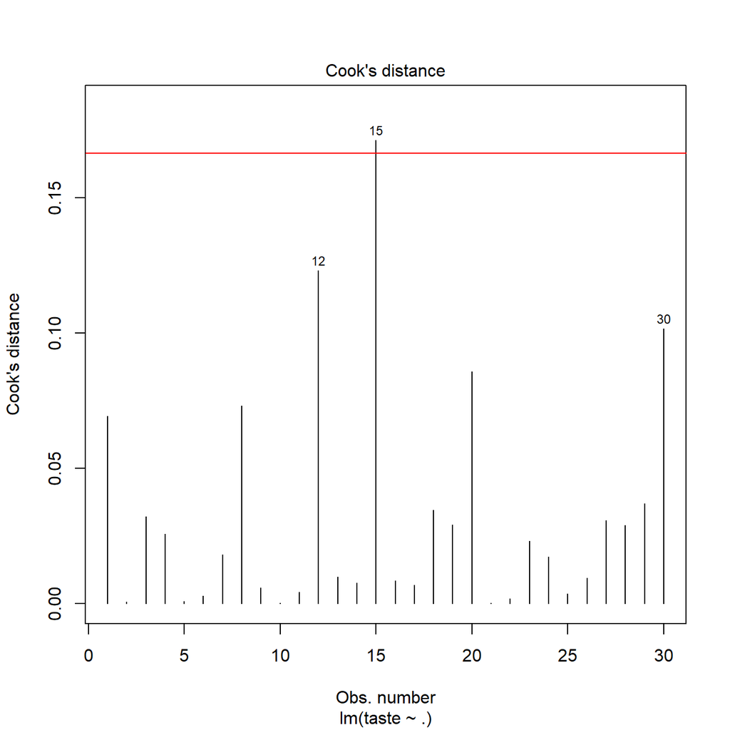

```r
> plot(model, which=4)
> abline(h=4/((n-p-2)), col="red")
```

Únicamente la observación 15 es influyente.

### f) Estructura del modelo

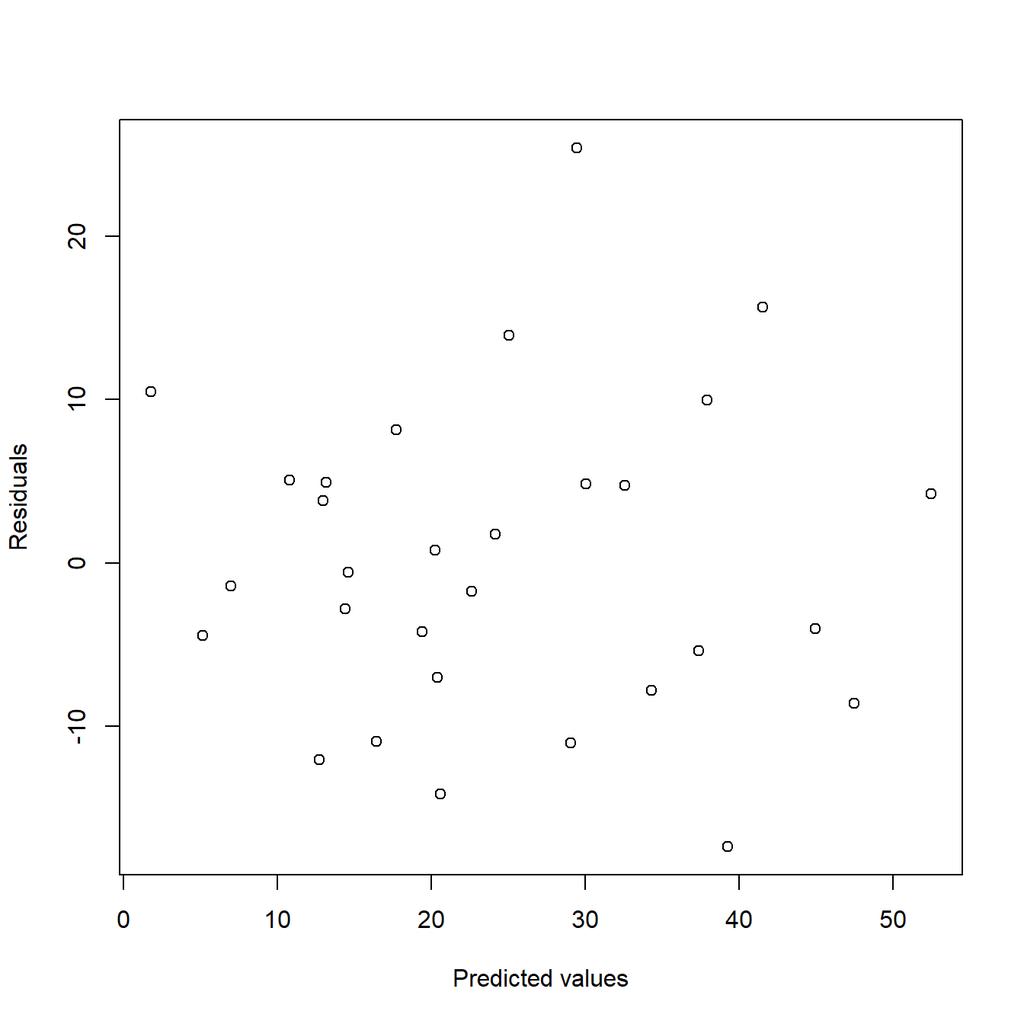

```r
> plot(fitted(model),residuals(model),xlab="Predicted values",ylab="Residuals")
```

La observación de los residuos representados con los valores ajustados no da señales de inadecuación del modelo. Observarlos con cada uno de los predictores tampoco.

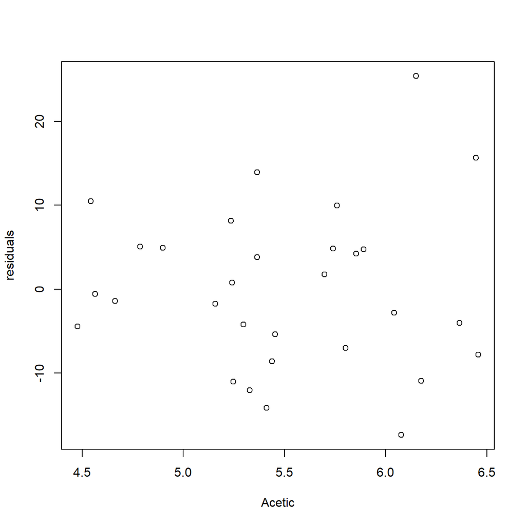

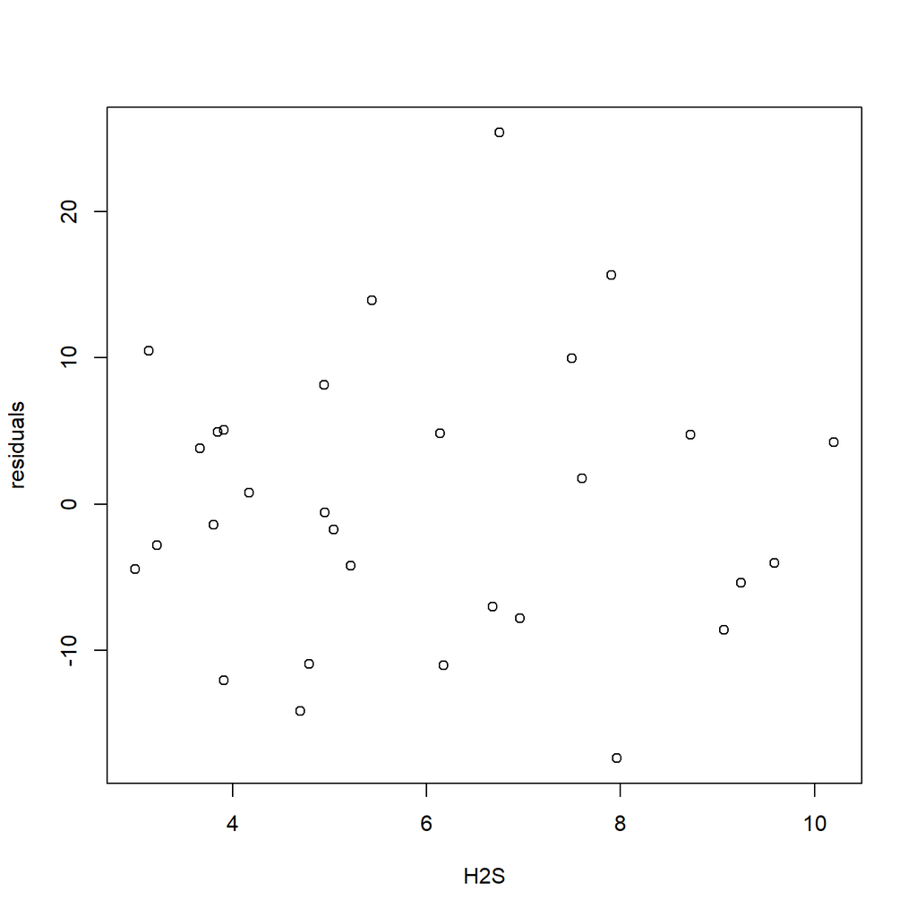

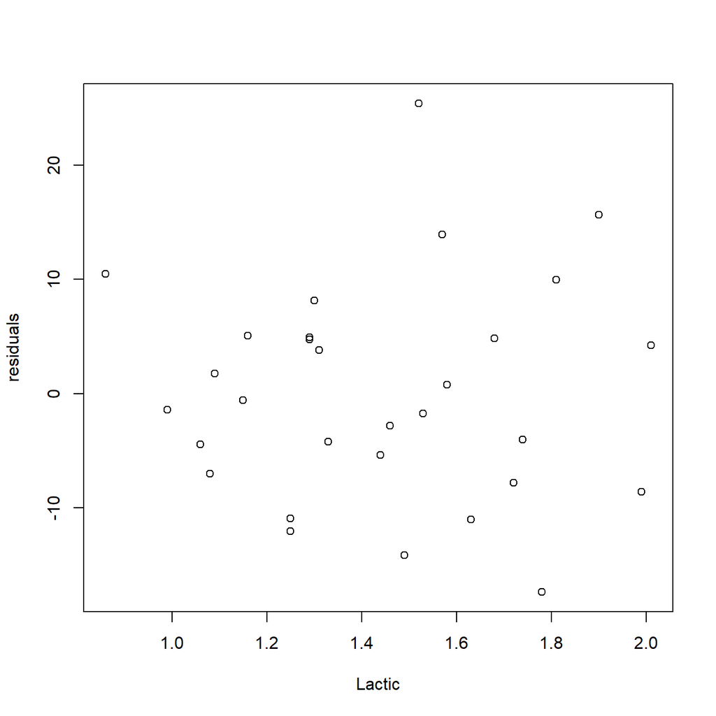

```r
> for (i in 2:4){
+   plot(datos[,i],residuals(model),xlab=colnames(cheddar)[i],ylab="residuals")
+ }
```

# Faraway. Capítulo 7.

## Problema 7.3. pág. 110

**Using the `divusa` data:**

### a) Números de condición

**Fit a regression model with `divorce` as the response and `unemployed`, `femlab`, `marriage`, `birth` and `military` as predictors. Compute the condition numbers and interpret their meanings.**

Cargamos los datos y ajustamos el modelo.

```r
> require(faraway)
```

```r
> data(divusa,package="faraway")
> dades <- divusa
> head(dades)
```

| year | divorce | unemployed | femlab | marriage | birth | military |
| --- | --- | --- | --- | --- | --- | --- |
| 1920 | 8.0 | 5.2 | 22.70 | 92.0 | 117.9 | 3.2247 |
| 1921 | 7.2 | 11.7 | 22.79 | 83.0 | 119.8 | 3.5614 |
| 1922 | 6.6 | 6.7 | 22.88 | 79.7 | 111.2 | 2.4553 |
| 1923 | 7.1 | 2.4 | 22.97 | 85.2 | 110.5 | 2.2065 |
| 1924 | 7.2 | 5.0 | 23.06 | 80.3 | 110.9 | 2.2889 |
| 1925 | 7.2 | 3.2 | 23.15 | 79.2 | 106.6 | 2.1735 |

```r
> model <- lm(divorce~unemployed+femlab+marriage+birth+military,data=dades)
> sumary(model)
```

```
             Estimate Std. Error t value  Pr(>|t|)
(Intercept)  2.487845   3.393779  0.7331   0.46594
unemployed  -0.111252   0.055925 -1.9893   0.05052
femlab       0.383649   0.030587 12.5430 < 2.2e-16
marriage     0.118674   0.024414  4.8609 6.772e-06
birth       -0.129959   0.015595 -8.3334 4.027e-12
military    -0.026734   0.014247 -1.8764   0.06471

n = 77, p = 6, Residual SE = 1.65042, R-Squared = 0.92
```

```r
> cor(divusa[,3:7])
```

|  | unemployed | femlab | marriage | birth | military |
| --- | --- | --- | --- | --- | --- |
| unemployed | 1.0000000 | -0.2574618 | -0.2707630 | -0.3138890 | -0.4002930 |
| femlab | -0.2574618 | 1.0000000 | -0.6486273 | -0.6040949 | 0.0512634 |
| marriage | -0.2707630 | -0.6486273 | 1.0000000 | 0.6737273 | 0.2581983 |
| birth | -0.3138890 | -0.6040949 | 0.6737273 | 1.0000000 | 0.1408986 |
| military | -0.4002930 | 0.0512634 | 0.2581983 | 0.1408986 | 1.0000000 |

De momento, no parece que haya signos de colinealidad en las relaciones dos a dos de las variables predictoras.

```r
> X <- model.matrix(model)
> XtX <- t(X) %*% X
> e <- eigen(XtX)
> e$val
```

```
[1] 1.174676e+06 2.126267e+04 1.613410e+04 6.206256e+03 1.857109e+03
[6] 2.364366e-01
```

```r
> sqrt(e$val[1]/e$val)
```

```
[1]    1.000000    7.432761    8.532703   13.757647   25.150132 2228.956893
```

Problema serio: hay un número de condición muy superior a 30.

### b) Factores de Inflación de la Varianza (VIFs)

**For the same model, compute the VIFs. Is there evidence that collinearity causes some predictors not to be significant? Explain.**

```r
> vif(X[,-1])   # vif(model)
```

```
unemployed     femlab   marriage      birth   military
  2.252888   3.613276   2.864864   2.585485   1.249596
```

Los factores de inflación de la varianza son bajos de manera que parece que el problema de multicolinealidad no es muy grave.

### c) Eliminación de predictores no significativos

**Does the removal of insignificant predictors from the model reduce the collinearity? Investigate.**

Probamos el modelo sin las predictoras menos significativas `unemployed` y `military`.

```r
> model2 <- update(model, .~.-unemployed-military)
> sumary(model2)
```

```
             Estimate Std. Error t value  Pr(>|t|)
(Intercept) -1.545451   2.212472 -0.6985    0.4871
femlab       0.413374   0.022745 18.1741 < 2.2e-16
marriage     0.126094   0.021988  5.7348 2.066e-07
birth       -0.116274   0.014120 -8.2347 5.101e-12

n = 77, p = 4, Residual SE = 1.69544, R-Squared = 0.91
```

```r
> X <- model.matrix(model2)
> e <- eigen(t(X) %*% X)
> e$val
```

```
[1] 1.158489e+06 2.097362e+04 6.208492e+03 5.871631e-01
```

```r
> sqrt(e$val[1]/e$val)
```

```
[1]    1.00000    7.43206   13.66007 1404.64495
```

```r
> vif(model2)
```

```
  femlab marriage    birth
1.893390 2.201891 2.008469
```

Vemos que eliminar las predictores no significativas mejora un poco los números de condición y los factores de inflación de la varianza, pero el problema persiste.

## Problema 7.4. pág. 110

**For the `longley` data, fit a model with `Employed` as the response and the other variables as predictors.**

Cargamos los datos y ajustamos el modelo.

```r
> data(longley)
> datos <- longley
> head(datos)
```

|  | GNP.deflator | GNP | Unemployed | Armed.Forces | Population | Year | Employed |
| --- | --- | --- | --- | --- | --- | --- | --- |
| 1947 | 83.0 | 234.289 | 235.6 | 159.0 | 107.608 | 1947 | 60.323 |
| 1948 | 88.5 | 259.426 | 232.5 | 145.6 | 108.632 | 1948 | 61.122 |
| 1949 | 88.2 | 258.054 | 368.2 | 161.6 | 109.773 | 1949 | 60.171 |
| 1950 | 89.5 | 284.599 | 335.1 | 165.0 | 110.929 | 1950 | 61.187 |
| 1951 | 96.2 | 328.975 | 209.9 | 309.9 | 112.075 | 1951 | 63.221 |
| 1952 | 98.1 | 346.999 | 193.2 | 359.4 | 113.270 | 1952 | 63.639 |

```r
> model <- lm(Employed~.,data=datos[,-6])
> sumary(model)
```

```
               Estimate Std. Error t value Pr(>|t|)
(Intercept)  92.4613078 35.1692479  2.6290  0.02520
GNP.deflator -0.0484628  0.1322477 -0.3665  0.72166
GNP           0.0720038  0.0317339  2.2690  0.04665
Unemployed   -0.0040387  0.0043854 -0.9210  0.37876
Armed.Forces -0.0056050  0.0028381 -1.9749  0.07652
Population   -0.4035087  0.3302641 -1.2218  0.24981

n = 16, p = 6, Residual SE = 0.48324, R-Squared = 0.99
```

### a) Números de condición

**Compute and comment on the condition numbers.**

```r
> X <- model.matrix(model)
> XtX <- t(X) %*% X
> e <- eigen(XtX)
> e$val
```

```
[1] 5.718589e+06 1.140735e+05 2.679828e+04 4.555382e+03 2.281188e+01
[6] 1.887834e-04
```

```r
> sqrt(e$val[1]/e$val)
```

```
[1] 1.000000e+00 7.080308e+00 1.460801e+01 3.543089e+01 5.006842e+02
[6] 1.740454e+05
```

Aparecen números de condición muy altos, que concuerdan bastante con el hecho de tener algunos parámetros muy lejos de ser significativos con un $R^2$ muy alto. Claramente tenemos un problema de multicolinealidad.

### b) Correlación

**Compute and comment on the correlations between the predictors.**

```r
> cor(datos[,1:5])
```

|  | GNP.deflator | GNP | Unemployed | Armed.Forces | Population |
| --- | --- | --- | --- | --- | --- |
| GNP.deflator | 1.0000000 | 0.9915892 | 0.6206334 | 0.4647442 | 0.9791634 |
| GNP | 0.9915892 | 1.0000000 | 0.6042609 | 0.4464368 | 0.9910901 |
| Unemployed | 0.6206334 | 0.6042609 | 1.0000000 | -0.1774206 | 0.6865515 |
| Armed.Forces | 0.4647442 | 0.4464368 | -0.1774206 | 1.0000000 | 0.3644163 |
| Population | 0.9791634 | 0.9910901 | 0.6865515 | 0.3644163 | 1.0000000 |

Algunas predictores están altamente correlacionados entre sí, con algunas correlaciones superiores a $0.9$.

### c) Factores de Inflación de la Varianza (VIFs)

**Compute the variance inflation factors.**

```r
> vif(model)
```

```
GNP.deflator          GNP   Unemployed Armed.Forces   Population
  130.829201   639.049777    10.786858     2.505775   339.011693
```

Como era de esperar de las comprobaciones anteriores, obtenemos factores de inflación de la varianza muy altos.

## Problema 7.5. pag. 110

**For the `prostate` data, fit a model with `lpsa` as the response and the other variables as predictors.**

Cargamos los datos y ajustamos el modelo.

```r
> require(faraway)
```

```r
> data(prostate,package="faraway")
> datos <- prostate
> head(datos)
```

| lcavol | lweight | age | lbph | svi | lcp | gleason | pgg45 | lpsa |
| --- | --- | --- | --- | --- | --- | --- | --- | --- |
| -0.5798185 | 2.7695 | 50 | -1.386294 | 0 | -1.38629 | 6 | 0 | -0.43078 |
| -0.9942523 | 3.3196 | 58 | -1.386294 | 0 | -1.38629 | 6 | 0 | -0.16252 |
| -0.5108256 | 2.6912 | 74 | -1.386294 | 0 | -1.38629 | 7 | 20 | -0.16252 |
| -1.2039728 | 3.2828 | 58 | -1.386294 | 0 | -1.38629 | 6 | 0 | -0.16252 |
| 0.7514161 | 3.4324 | 62 | -1.386294 | 0 | -1.38629 | 6 | 0 | 0.37156 |
| -1.0498221 | 3.2288 | 50 | -1.386294 | 0 | -1.38629 | 6 | 0 | 0.76547 |

```r
> model <- lm(lpsa~.,data=datos)
> sumary(model)
```

```
              Estimate Std. Error t value  Pr(>|t|)
(Intercept)  0.6693367  1.2963875  0.5163  0.606934
lcavol       0.5870218  0.0879203  6.6767 2.111e-09
lweight      0.4544674  0.1700124  2.6731  0.008955
age         -0.0196372  0.0111727 -1.7576  0.082293
lbph         0.1070540  0.0584492  1.8316  0.070398
svi          0.7661573  0.2443091  3.1360  0.002329
lcp         -0.1054743  0.0910135 -1.1589  0.249638
gleason      0.0451416  0.1574645  0.2867  0.775033
pgg45        0.0045252  0.0044212  1.0235  0.308860

n = 97, p = 9, Residual SE = 0.70842, R-Squared = 0.65
```

### a) Números de condición

**Compute and comment on the condition numbers.**

```r
> X <- model.matrix(model)
> show(round(XtX <- t(X) %*% X,1))
```

```
            (Intercept) lcavol lweight      age  lbph    svi    lcp gleason
(Intercept)        97.0  131.0   354.3   6195.0   9.7   21.0  -17.4   655.0
lcavol            131.0  310.1   489.2   8552.8  17.6   53.6   83.4   919.6
lweight           354.3  489.2  1317.9  22737.6  65.6   78.9  -56.9  2392.5
age              6195.0 8552.8 22737.6 400971.0 984.8 1376.0 -983.6 41971.0
lbph                9.7   17.6    65.6    984.8 203.0   -2.8   -3.1    73.6
svi                21.0   53.6    78.9   1376.0  -2.8   21.0   33.6   151.0
lcp               -17.4   83.4   -56.9   -983.6  -3.1   33.6  190.8   -67.6
gleason           655.0  919.6  2392.5  41971.0  73.6  151.0  -67.6  4473.0
pgg45            2365.0 4576.7  8707.0 156609.0 545.5 1025.0 1966.7 17440.0
               pgg45
(Intercept)   2365.0
lcavol        4576.7
lweight       8707.0
age         156609.0
lbph           545.5
svi           1025.0
lcp           1966.7
gleason      17440.0
pgg45       134027.0
```

```r
> e <- eigen(XtX)
> round(e$val, 3)
```

```
[1] 479175.193  61910.256    211.091    175.657     65.461     44.561     20.252
[8]      8.094      0.295
```

```r
> round(sqrt(e$val[1]/e$val),3)
```

```
[1]    1.000    2.782   47.644   52.229   85.557  103.698  153.822  243.311
[9] 1275.025
```

Aparecen algunos números de condición muy altos lo que muestra un problema de multicolinealidad.

```r
> cor(datos[-9])
```

|  | lcavol | lweight | age | lbph | svi | lcp | gleason | pgg45 |
| --- | --- | --- | --- | --- | --- | --- | --- | --- |
| lcavol | 1.0000000 | 0.1941284 | 0.2249999 | 0.0273497 | 0.5388450 | 0.6753106 | 0.4324171 | 0.4336522 |
| lweight | 0.1941284 | 1.0000000 | 0.3075247 | 0.4349317 | 0.1087782 | 0.1002389 | -0.0012830 | 0.0508462 |
| age | 0.2249999 | 0.3075247 | 1.0000000 | 0.3501859 | 0.1176580 | 0.1276678 | 0.2688916 | 0.2761124 |
| lbph | 0.0273497 | 0.4349317 | 0.3501859 | 1.0000000 | -0.0858433 | -0.0069994 | 0.0778204 | 0.0784600 |
| svi | 0.5388450 | 0.1087782 | 0.1176580 | -0.0858433 | 1.0000000 | 0.6731112 | 0.3204122 | 0.4576476 |
| lcp | 0.6753106 | 0.1002389 | 0.1276678 | -0.0069994 | 0.6731112 | 1.0000000 | 0.5148299 | 0.6315281 |
| gleason | 0.4324171 | -0.0012830 | 0.2688916 | 0.0778204 | 0.3204122 | 0.5148299 | 1.0000000 | 0.7519045 |
| pgg45 | 0.4336522 | 0.0508462 | 0.2761124 | 0.0784600 | 0.4576476 | 0.6315281 | 0.7519045 | 1.0000000 |

Algunas predictoras están correlacionados con otras, aunque no con valores de correlación altísimos. Destaca `gleason` que tiene correlaciones altas con alguna otra predictora y a la vez es el predictor menos significativo del modelo.

### c) Factores de Inflación de la Varianza (VIFs)

**Compute the variance inflation factors.**

```r
> vif(model)
```

```
  lcavol  lweight      age     lbph      svi      lcp  gleason    pgg45
2.054115 1.363704 1.323599 1.375534 1.956881 3.097954 2.473411 2.974361
```

Obtenemos factores de inflación de la varianza moderados.